# Matematicko-fyzikálne rozbory meraní v medicíne

Skúška 2020/2021

Daniela Adamkovičová

2.2.2021

V tomto notebooku som využila nasledujúce knižnice:

```r
library(ggpubr)
library(moments)
library(tidyverse)
library(dplyr)
library(ggplot2)
library(pastecs)
library(psych)
library(gt)
library(glue)
library(reshape)
library(basicTrendline)
library(e1071)
```

**Výskumný zámer:**

Porovnanie diagnostickej výkonnosti a zhody Magnetickej Rezonancie (MR) a Sonografie (ECHO) pri stanovení NC/C pomeru (NC/C - nekompaktná vrstva myokardu/kompaktná vrstva).

V tomto bloku kódu som si načítala dáta.

```r
data <- read.delim("https://raw.githubusercontent.com//DanielaAdamkovicova//DanielaAdamkovicova//master//data.csv", sep = ";")
data
```

```
##    pacient vek pohlavie LK.cm.MR LK.cm.ECHO EF...MR EF...ECHO
## 1       43  28        Z      4.2        4.0      50        55
## 2       50  50        M      4.3        4.5      50        55
## 3       52  14        M      5.6        5.5      52        55
## 4       55  50        M      5.7        5.3      47        50
## 5       57  19        M      4.8        5.0      57        60
## 6       59  29        Z      5.3        5.0      60        60
## 7       56  38        Z      5.0        4.8      49        60
## 8       60  31        M      6.0        6.2      41        45
## 9       35  24        M      4.5        4.0      62        65
## 10      37  16        M      4.4        4.3      60        65
## 11      41  19        M      4.3        4.0      60        70
## 12      51  42        M      4.5        4.5      60        60
## 13       4  17        M      3.5        3.5      48        50
## 14       5  22        Z      3.0        3.5      45        50
```

[output cut: 46 more lines]

**Deskriptívna štatistika**

Tu som sa pokúsila spraviť kompletnú popisnú štatistiku pre premennú Veľkosť ľavej komory (ĽK) osobitne pre hodnotu stanovenú metódou MR a osobitne pre hodnotu stanovenú metódou Echo.

```r
LK_MR <- as.numeric(unlist(data["LK.cm.MR"]))
LK_ECHO <- as.numeric(unlist(data["LK.cm.ECHO"]))
lk_mr_stat <- data.frame(as.list(stat.desc(LK_MR)))
lk_echo_stat <- data.frame(as.list(stat.desc(LK_ECHO)))

lk_mr_stat$Skewness = skewness(LK_MR)
lk_mr_stat$Kurtosis = kurtosis(LK_MR)
lk_echo_stat$Skewness = skewness(LK_ECHO)
lk_echo_stat$Kurtosis = kurtosis(LK_ECHO)

lk_mr_muzi <- filter(data, pohlavie == "M")
lk_mr_zeny <- filter(data, pohlavie == "Z")
lk_mr_stat %>%
  dplyr::rename(
    Number_of_elements = nbr.val,
    Standard_Error = SE.mean,
    Standard_Deviation = std.dev,
    Sample_Variance = var
  )%>%
   dplyr::select(-nbr.null,-nbr.na, -CI.mean.0.95
, -coef.var) %>%
 gt() %>%
  tab_header(
    title = "LK_MR_STAT"
  ) %>%
  fmt_number(
    columns = vars(Number_of_elements,min,max,range,sum,median,mean,Standard_Error,Sample_Variance,Standard_Deviation)
  )
```

LK_MR_STAT

| Number_of_elements | min | max | range | sum | median | mean | Standard_Error | Sample_Variance | Standard_Deviation | Skewness | Kurtosis |
| --- | --- | --- | --- | --- | --- | --- | --- | --- | --- | --- | --- |
| 60.00 | 3.00 | 6.40 | 3.40 | 283.50 | 4.65 | 4.72 | 0.09 | 0.51 | 0.71 | 0.06467378 | -0.09358072 |

```r
lk_echo_stat %>%
  dplyr::rename(
    Number_of_elements = nbr.val,
    Standard_Error = SE.mean,
    Standard_Deviation = std.dev,
    Sample_Variance = var

  )%>%
   dplyr::select(-nbr.null,-nbr.na, -CI.mean.0.95
, -coef.var) %>%
 gt() %>%
  tab_header(
    title = "LK_ECHO_STAT"
  ) %>%
  fmt_number(
    columns = vars(Number_of_elements,min,max,range,sum,median,mean,Standard_Error,Sample_Variance,Standard_Deviation)

  )
```

LK_ECHO_STAT

| Number_of_elements | min | max | range | sum | median | mean | Standard_Error | Sample_Variance | Standard_Deviation | Skewness | Kurtosis |
| --- | --- | --- | --- | --- | --- | --- | --- | --- | --- | --- | --- |
| 60.00 | 3.50 | 6.20 | 2.70 | 280.60 | 4.50 | 4.68 | 0.09 | 0.53 | 0.73 | 0.1457642 | -0.7492319 |

**Bar plot**

Ďalej som spravila bar plot stredných hodnôt pre premennú Veľkosť ľavej komory (ĽK) osobitne pre hodnotu stanovenú metódou MR (pre mužov a ženy) a osobitne pre hodnotu stanovenú metódou ECHO (pre mužov a pre ženy).

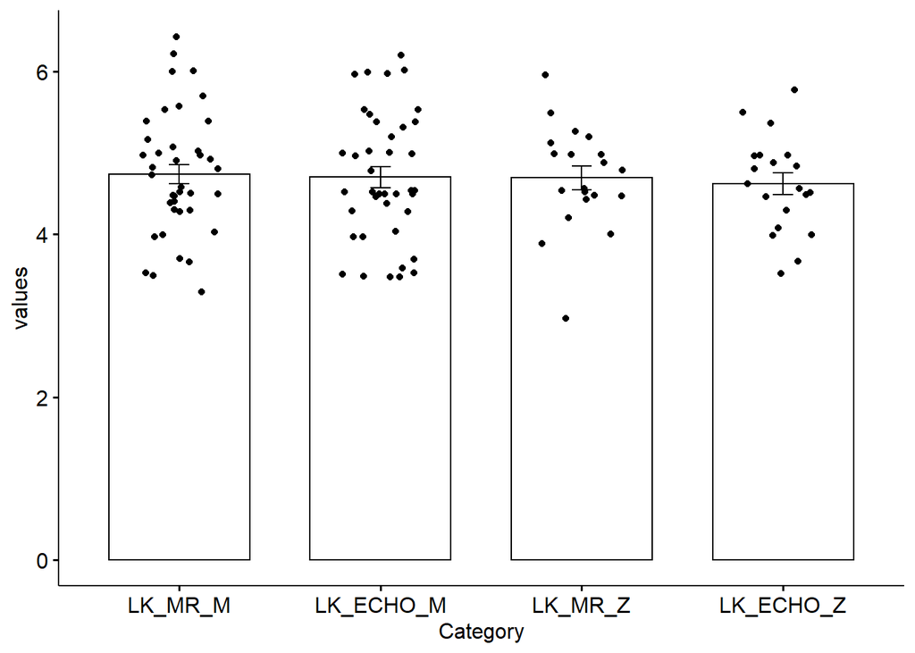

```r
categories <- c("LK_MR_M","LK_ECHO_M","LK_MR_Z","LK_ECHO_Z")
values <- c(lk_mr_muzi$LK.cm.MR, lk_mr_muzi$LK.cm.ECHO, lk_mr_zeny$LK.cm.MR, lk_mr_zeny$LK.cm.ECHO)
data_2 <- data.frame(values)
data_2["Category"] <- NA
data_2$Category[1:40] = "LK_MR_M"
data_2$Category[41:80] = "LK_ECHO_M"
data_2$Category[81:100] = "LK_MR_Z"
data_2$Category[101:120] = "LK_ECHO_Z"
ggbarplot(data_2, x="Category", y="values",
       add = c("mean_se", "jitter"))
```

**XY graf**

XY graf pre hodnoty veľkosti ĽK na MR a ECHU.

```
##
## Call:
## lm(formula = y ~ x)
##
## Residuals:
##       Min        1Q    Median        3Q       Max
## -0.489366 -0.197166 -0.005567  0.111634  0.588633
##
## Coefficients:
##             Estimate Std. Error t value Pr(>|t|)
## (Intercept) 0.197362   0.241223  0.8182   0.4166
## x           0.948001   0.050491 18.7756   <2e-16 ***
## ---
## Signif. codes:  0 '***' 0.001 '**' 0.01 '*' 0.05 '.' 0.1 ' ' 1
##
## Residual standard error: 0.27633 on 58 degrees of freedom
## Multiple R-squared:  0.85872,    Adjusted R-squared:  0.85628
## F-statistic: 352.52 on 1 and 58 DF,  p-value: < 2.22e-16
##
##
## N: 60 , AIC: 19.9 , BIC:  26.183
## Residual Sum of Squares:  4.4288
```

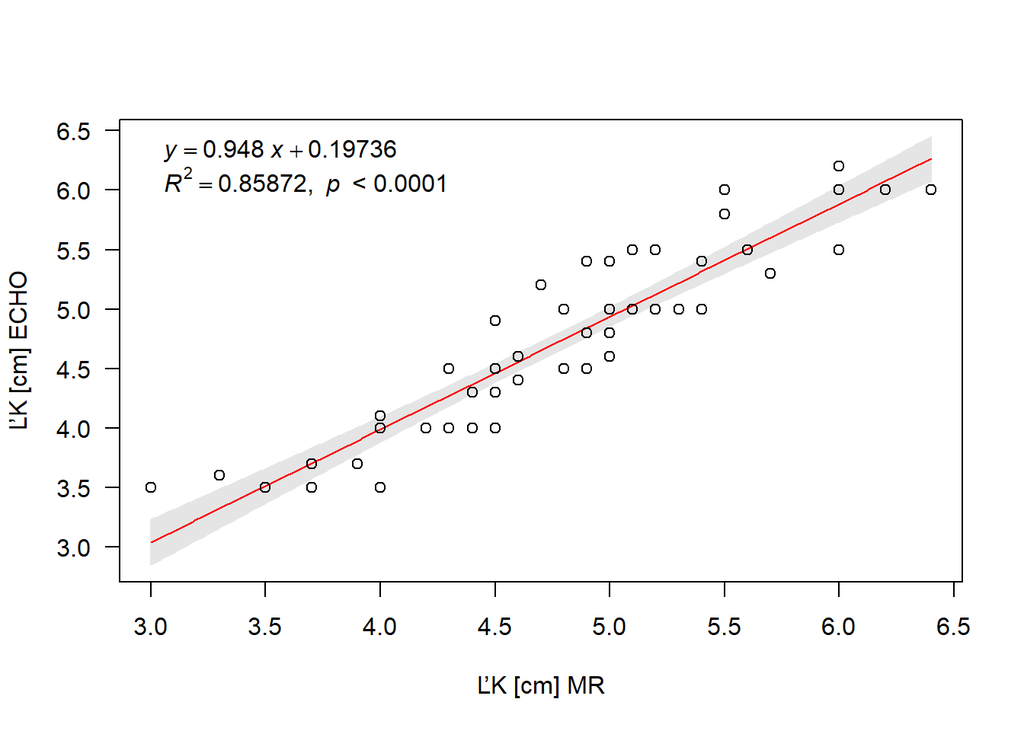

```r
trendline(data$LK.cm.MR,data$LK.cm.ECHO,model="line2P",plot=FALSE,linecolor="red", xlab="ĽK [cm] MR", ylab="ĽK [cm] ECHO")
```

Z grafického zobrazenia dát vidíme, že dáta spolu korelujú vo vysokej miere (0,9 ≤ r => vysoká významnosť).

Hodnota korelačného koeficietu:

```r
r <- sqrt(0.85872)
r
```

```
## [1] 0.9266715
```

**XY graf**

XY graf pre hodnoty veľkosti ĽK na MR a ejekčnej frakcie MR.

```
##
## Call:
## lm(formula = y ~ x)
##
## Residuals:
##      Min       1Q   Median       3Q      Max
## -27.4038  -4.9534   1.2678   6.9320  13.8214
##
## Coefficients:
##             Estimate Std. Error t value  Pr(>|t|)
## (Intercept)  39.0526     7.9119  4.9360 7.081e-06 ***
## x             2.2252     1.6561  1.3437    0.1843
## ---
## Signif. codes:  0 '***' 0.001 '**' 0.01 '*' 0.05 '.' 0.1 ' ' 1
##
## Residual standard error: 9.0634 on 58 degrees of freedom
## Multiple R-squared:  0.030189,   Adjusted R-squared:  0.013468
## F-statistic: 1.8054 on 1 and 58 DF,  p-value: 0.18429
##
##
## N: 60 , AIC: 438.75 , BIC:  445.03
## Residual Sum of Squares:  4764.4
```

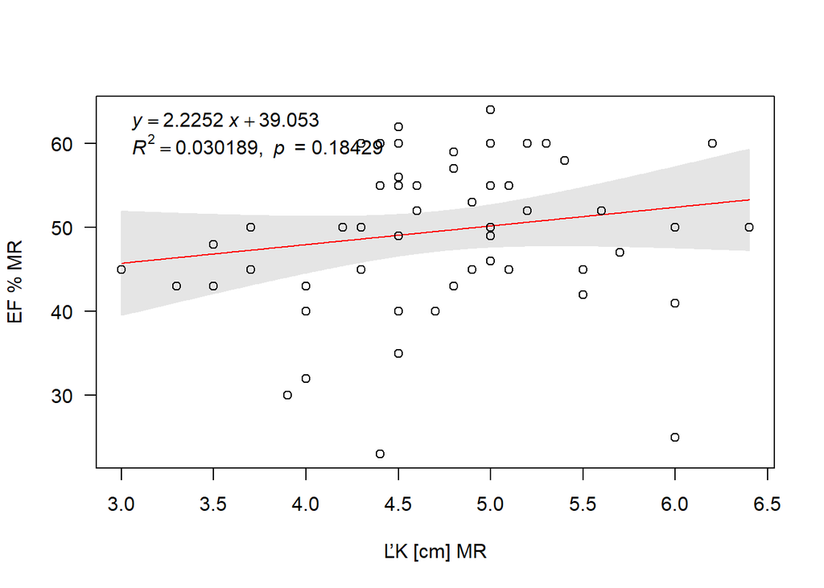

```r
trendline(data$LK.cm.MR,data$EF...MR,model="line2P",plot=FALSE,linecolor="red",xlab="ĽK [cm] MR", ylab="EF % MR")
```

Medzi dátami je nízka korelácia (0,3 > r => nízka tesnosť) a veľkosť komory len málo závisí od ejekčnej frakcie.

Hodnota korelačného koeficietu:

```r
r <- sqrt(0.030189)
r
```

```
## [1] 0.1737498
```

**Regresná analýza**

```r
fit <- lm(formula = data$LK.cm.MR ~ data$EF...MR, data = data)
summary(fit)
```

```
##
## Call:
## lm(formula = data$LK.cm.MR ~ data$EF...MR, data = data)
##
## Residuals:
##      Min       1Q   Median       3Q      Max
## -1.66305 -0.40675 -0.02661  0.32590  1.66912
##
## Coefficients:
##              Estimate Std. Error t value Pr(>|t|)
## (Intercept)   4.05254    0.50874   7.966 6.99e-11 ***
## data$EF...MR  0.01357    0.01010   1.344    0.184
## ---
## Signif. codes:  0 '***' 0.001 '**' 0.01 '*' 0.05 '.' 0.1 ' ' 1
##
## Residual standard error: 0.7077 on 58 degrees of freedom
## Multiple R-squared:  0.03019,    Adjusted R-squared:  0.01347
## F-statistic: 1.805 on 1 and 58 DF,  p-value: 0.1843
```

Na základe znalosti hodnoty ĽK z MR nevieme dobre predpovedať ejekčnú frakciu (EF MR) ľavej komory.